# Cardio_Good_Fitness

## Class Project: Cardio Good Fitness Project

In the first step, I import the Python Libaries that are required by Python to complete the data analysis.

```python
import numpy as np
import pandas as pd
import matplotlib.pyplot as plt
import seaborn as sns
import warnings
warnings.filterwarnings("ignore")
from PIL import Image
```

### Importing the Data

Read the CSV file to obtain the Cardio Good Fitness Data from *CardioGoodFitness.csv*

```python
cardio_good_fitness = pd.read_csv('CardioGoodFitness.csv')
```

### Use info() to obtain the column names and data types

```python
cardio_good_fitness.info()
```

```
<class 'pandas.core.frame.DataFrame'>
RangeIndex: 180 entries, 0 to 179
Data columns (total 9 columns):
 #   Column         Non-Null Count  Dtype
---  ------         --------------  -----
 0   Product        180 non-null    object
 1   Age            180 non-null    int64
 2   Gender         180 non-null    object
 3   Education      180 non-null    int64
 4   MaritalStatus  180 non-null    object
 5   Usage          180 non-null    int64
 6   Fitness        180 non-null    int64
 7   Income         180 non-null    int64
 8   Miles          180 non-null    int64
dtypes: int64(6), object(3)
memory usage: 12.8+ KB
```

### Observations

1. The data consist of 180 rows and 9 columns
2. Three *catagorical* data columns are **Product**, **Gender** and **MaritalStatus**
3. The remaining six columns are *quantitative* and *discrete*

### Checking for missing values

It is important to first verify that there are no missing value in the data. In this next cell I use a function _missing*check* to process the data frame and check for missing values.

```python
def missing_check(df):
    total = df.isnull().sum().sort_values(ascending = False)
    percent = (df.isnull().sum() / df.isnull().count()).sort_values(ascending = False)
    missing_data = pd.concat([total, percent], axis = 1, keys = ['Total', 'Percent'])
    return missing_data
missing_check(cardio_good_fitness)
```

|  | Total | Percent |
| --- | --- | --- |
| Miles | 0 | 0.0 |
| Income | 0 | 0.0 |
| Fitness | 0 | 0.0 |
| Usage | 0 | 0.0 |
| MaritalStatus | 0 | 0.0 |
| Education | 0 | 0.0 |
| Gender | 0 | 0.0 |
| Age | 0 | 0.0 |
| Product | 0 | 0.0 |

## Observations

The table shows that there are no missing values in the data frame.

## Inspecting the Data

In the next section, I use the head() method to view the first five rows of data in the data frame. This will allow a brief analysis of the data to form a mental model of the available data and how it might be used for analysis.

```python
cardio_good_fitness.head()
```

|  | Product | Age | Gender | Education | MaritalStatus | Usage | Fitness | Income | Miles |
| --- | --- | --- | --- | --- | --- | --- | --- | --- | --- |
| 0 | TM195 | 18 | Male | 14 | Single | 3 | 4 | 29562 | 112 |
| 1 | TM195 | 19 | Male | 15 | Single | 2 | 3 | 31836 | 75 |
| 2 | TM195 | 19 | Female | 14 | Partnered | 4 | 3 | 30699 | 66 |
| 3 | TM195 | 19 | Male | 12 | Single | 3 | 3 | 32973 | 85 |
| 4 | TM195 | 20 | Male | 13 | Partnered | 4 | 2 | 35247 | 47 |

### Observations

1. I see five rows of data for the available nine columns
2. The data will contain one or more products, gender of male or female, marital status of single or partnered
3. A discrete score is assigned for age, education, usage, fitness, income, and miles

### Obtaining the Unique Products

I use the unique() method to discover the unique products that are represented in the data frame.

```python
cardio_good_fitness['Product'].unique()
```

```
array(['TM195', 'TM498', 'TM798'], dtype=object)
```

### Observations

1. There are three products described in the data frame: TM195, TM498, and TM798
2. The column represents catagorical data for the sample

### Exploring the range, average, and variance of the discrete data

The six discrete columns can be analyzed to gain understanding of the spread, range, average, skewness.

```python
cardio_good_fitness.describe()
```

|  | Age | Education | Usage | Fitness | Income | Miles |
| --- | --- | --- | --- | --- | --- | --- |
| count | 180.000000 | 180.000000 | 180.000000 | 180.000000 | 180.000000 | 180.000000 |
| mean | 28.788889 | 15.572222 | 3.455556 | 3.311111 | 53719.577778 | 103.194444 |
| std | 6.943498 | 1.617055 | 1.084797 | 0.958869 | 16506.684226 | 51.863605 |
| min | 18.000000 | 12.000000 | 2.000000 | 1.000000 | 29562.000000 | 21.000000 |
| 25% | 24.000000 | 14.000000 | 3.000000 | 3.000000 | 44058.750000 | 66.000000 |
| 50% | 26.000000 | 16.000000 | 3.000000 | 3.000000 | 50596.500000 | 94.000000 |
| 75% | 33.000000 | 16.000000 | 4.000000 | 4.000000 | 58668.000000 | 114.750000 |
| max | 50.000000 | 21.000000 | 7.000000 | 5.000000 | 104581.000000 | 360.000000 |

### Observations

1. Age range is 18 - 50 with the average age of the customer being roughly 29
2. Education range is 12 - 21 with the average of roughly 16
3. Usage range is 2 - 7 with the average 3.5
4. Fitness ranges from 1 to 5, average being 3
5. Income ranges from 30k - 105k with average of 53k
6. Miles ranges from 21 to 360 with a mean distance of 103 miles

### Looking at Distribution Visually

I plot a histogram for each discrete data column to analyze the distribution of the data.

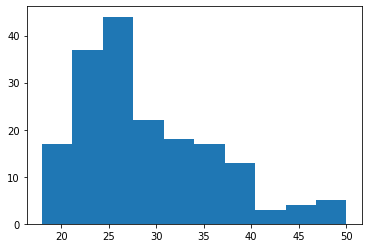

```python
plt.hist(cardio_good_fitness['Age']);
```

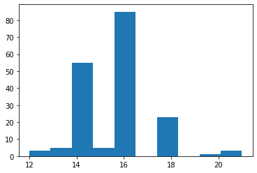

```python
plt.hist(cardio_good_fitness['Education']);
```

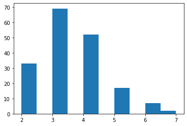

```python
plt.hist(cardio_good_fitness['Usage']);
```

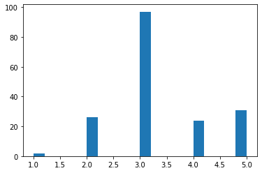

```python
plt.hist(cardio_good_fitness['Fitness'], bins = 20);
```

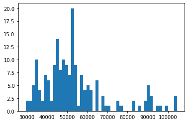

```python
plt.hist(cardio_good_fitness['Income'], bins = 50);
```

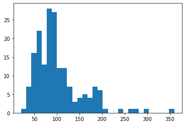

```python
plt.hist(cardio_good_fitness['Miles'], bins = 30);
```

### Observations

1. Age, Usage, Income, and Miles show a right skewness in the data
2. Miles has some large outliers, but the mean value still seems reasonable
3. Income appears to be bimodal, indicating possibly two different income brackets of customers
4. Usage and Fitness appear to be more ordinal in nature from examining the histogram

### Distributions

Next I plot the shape of the data distributions for analysis

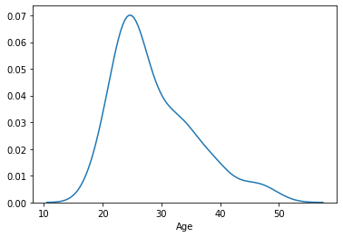

```python
age = cardio_good_fitness['Age']
sns.distplot(age, hist = False);
```

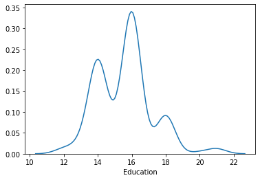

```python
education = cardio_good_fitness['Education']
sns.distplot(education, hist = False);
```

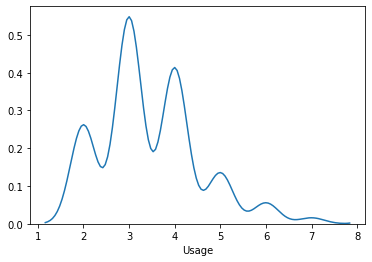

```python
usage = cardio_good_fitness['Usage']
sns.distplot(usage, hist = False);
```

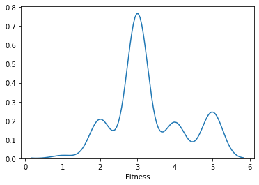

```python
fitness = cardio_good_fitness['Fitness']
sns.distplot(fitness, hist = False);
```

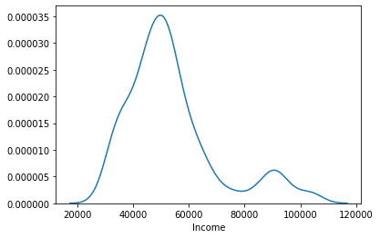

```python
income = cardio_good_fitness['Income']
sns.distplot(income, hist = False);
```

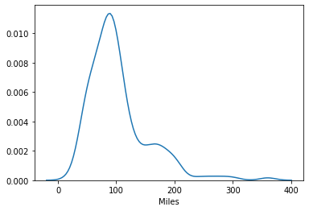

```python
miles = cardio_good_fitness['Miles']
sns.distplot(miles, hist = False);
```

### Multivariate Analysis

I now create a pair plot of the data for bivariate analysis.

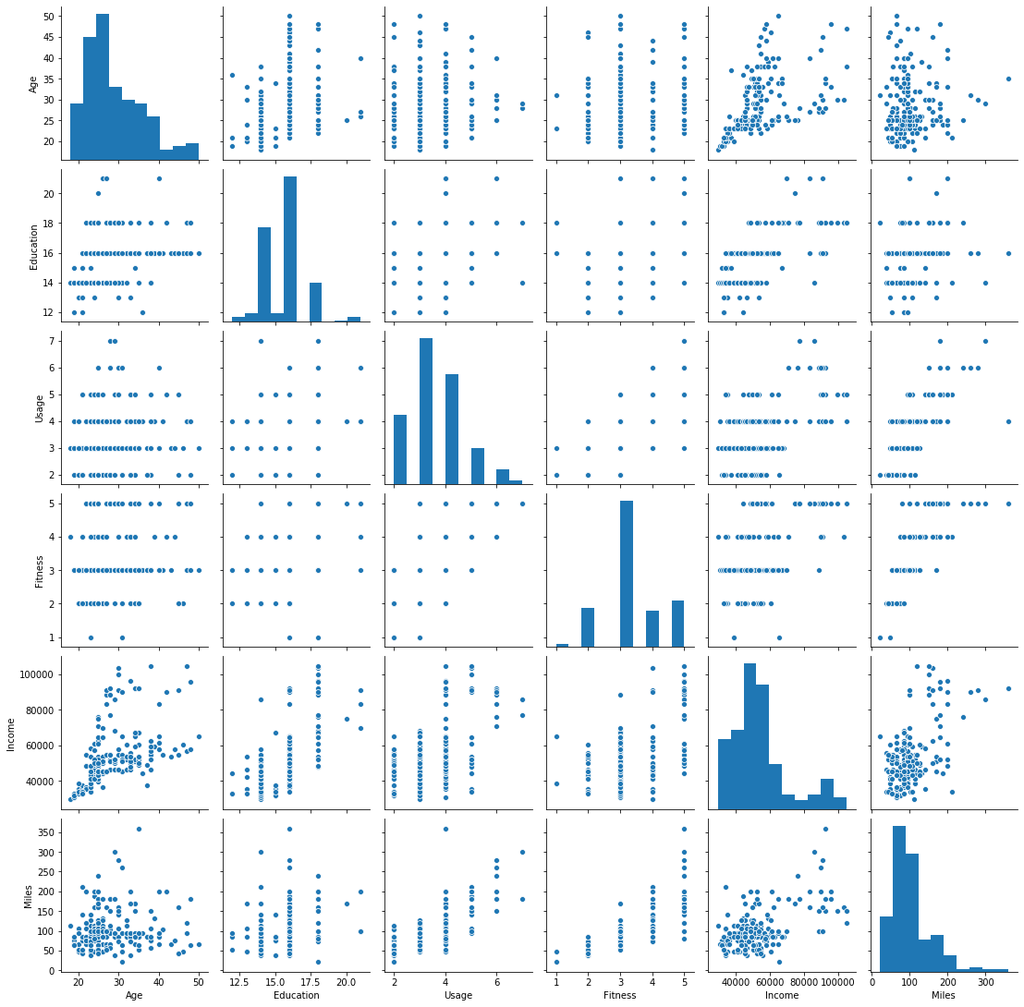

```python
sns.pairplot(cardio_good_fitness);
```

```python
cardio_good_fitness.corr()
```

|  | Age | Education | Usage | Fitness | Income | Miles |
| --- | --- | --- | --- | --- | --- | --- |
| Age | 1.000000 | 0.280496 | 0.015064 | 0.061105 | 0.513414 | 0.036618 |
| Education | 0.280496 | 1.000000 | 0.395155 | 0.410581 | 0.625827 | 0.307284 |
| Usage | 0.015064 | 0.395155 | 1.000000 | 0.668606 | 0.519537 | 0.759130 |
| Fitness | 0.061105 | 0.410581 | 0.668606 | 1.000000 | 0.535005 | 0.785702 |
| Income | 0.513414 | 0.625827 | 0.519537 | 0.535005 | 1.000000 | 0.543473 |
| Miles | 0.036618 | 0.307284 | 0.759130 | 0.785702 | 0.543473 | 1.000000 |

### Observations

1. There's a correlation between fitness and miles or usage, indicating that customers with higher miles or usage experience greater health levels
2. The strongest correlation appears to be fitness to miles, so perhaps focusing on more miles is better than on the number of days a week the customer uses the product
3. There's a correlation between miles and usage
4. Extremely low correlation between age and miles, fitness, and usage

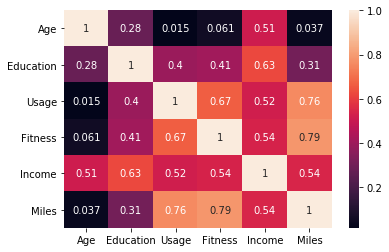

```python
sns.heatmap(cardio_good_fitness.corr(), annot = True);
```

```python
tm195 = cardio_good_fitness[cardio_good_fitness['Product'] == 'TM195']
tm498 = cardio_good_fitness[cardio_good_fitness['Product'] == 'TM498']
tm798 = cardio_good_fitness[cardio_good_fitness['Product'] == 'TM798']
tm195_pcnt = len(tm195) / len(cardio_good_fitness) * 100
tm498_pcnt = len(tm498) / len(cardio_good_fitness) * 100
tm798_pcnt = len(tm798) / len(cardio_good_fitness) * 100
print('tm195', tm195_pcnt, '% tm498', tm498_pcnt, '% tm798', tm798_pcnt, '%')
```

```
tm195 44.44444444444444 % tm498 33.33333333333333 % tm798 22.22222222222222 %
```

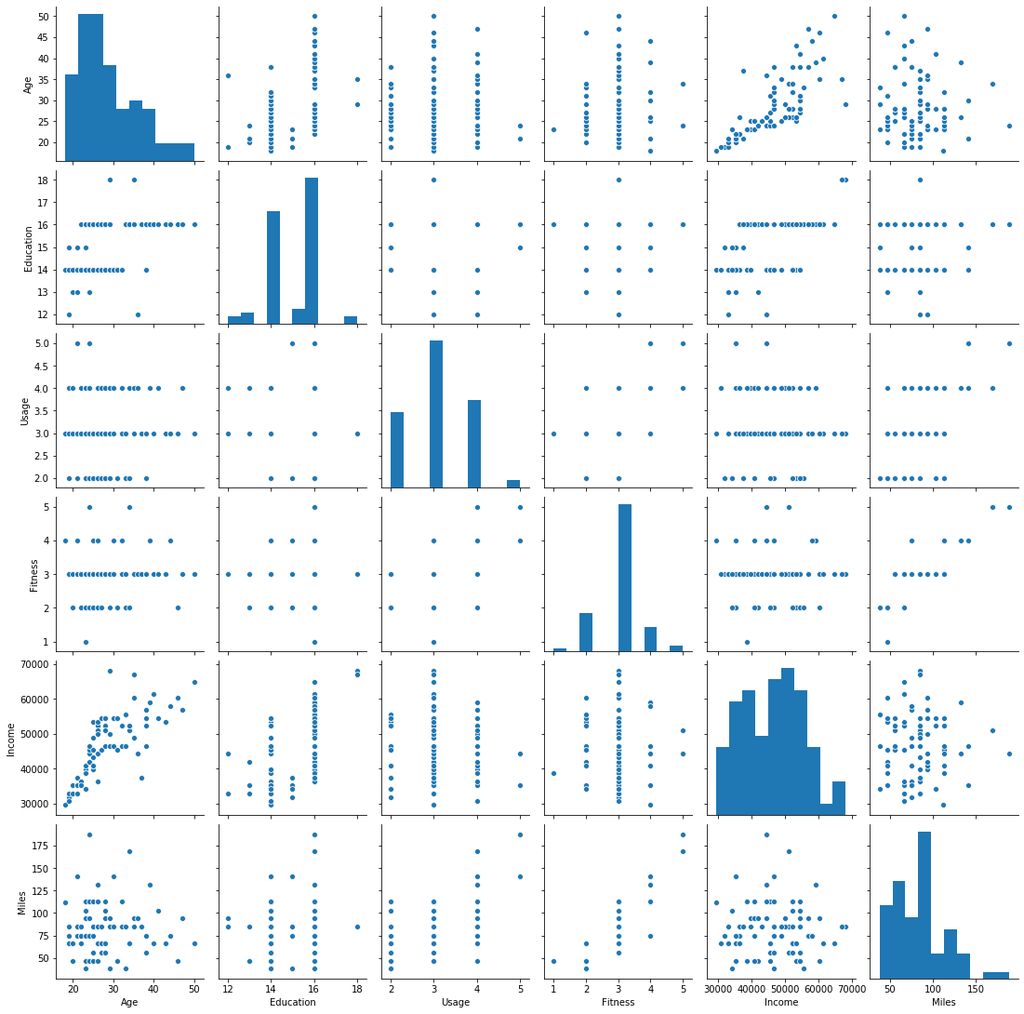

```python
sns.pairplot(tm195);
```

The correlation is strong for product tm195 between miles and fitness:

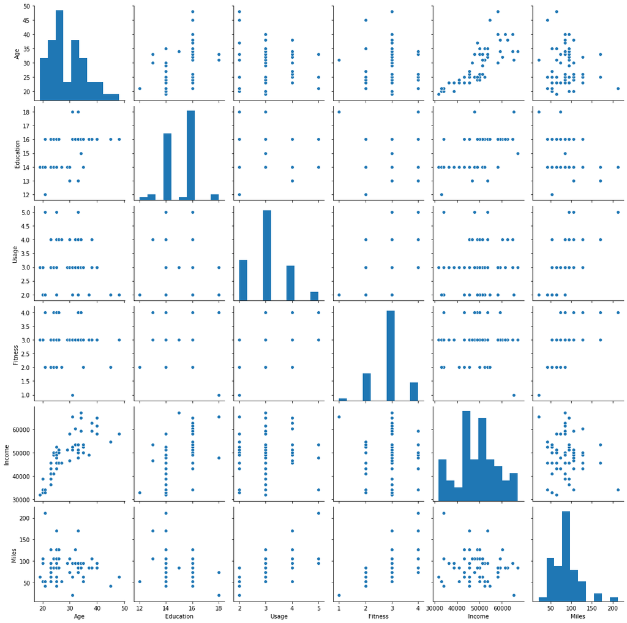

```python
sns.pairplot(tm498);
```

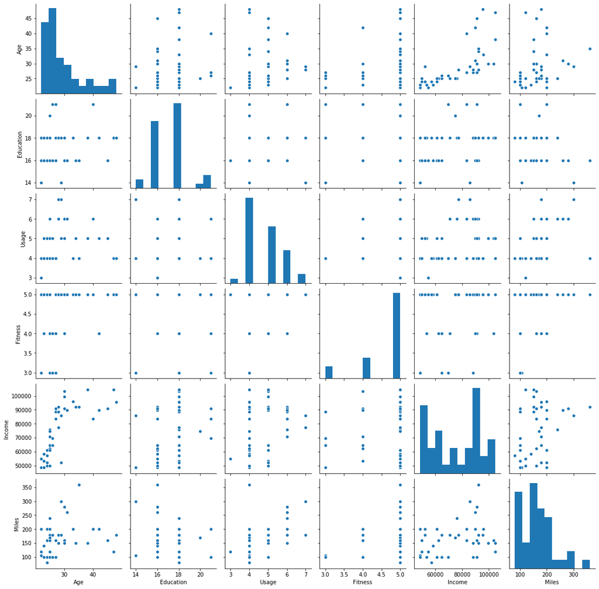

```python
sns.pairplot(tm798);
```

```python
tm195.corr()
```

|  | Age | Education | Usage | Fitness | Income | Miles |
| --- | --- | --- | --- | --- | --- | --- |
| Age | 1.000000 | 0.336268 | -0.015342 | 0.054469 | 0.751831 | -0.064632 |
| Education | 0.336268 | 1.000000 | 0.169369 | 0.111379 | 0.446551 | 0.111956 |
| Usage | -0.015342 | 0.169369 | 1.000000 | 0.468825 | -0.052227 | 0.645576 |
| Fitness | 0.054469 | 0.111379 | 0.468825 | 1.000000 | 0.005906 | 0.826177 |
| Income | 0.751831 | 0.446551 | -0.052227 | 0.005906 | 1.000000 | -0.039377 |
| Miles | -0.064632 | 0.111956 | 0.645576 | 0.826177 | -0.039377 | 1.000000 |

```python
tm498.corr()
```

|  | Age | Education | Usage | Fitness | Income | Miles |
| --- | --- | --- | --- | --- | --- | --- |
| Age | 1.000000 | 0.472956 | -0.078458 | -0.026730 | 0.787550 | -0.124710 |
| Education | 0.472956 | 1.000000 | -0.112105 | -0.094660 | 0.540207 | -0.240293 |
| Usage | -0.078458 | -0.112105 | 1.000000 | 0.349996 | 0.073367 | 0.673648 |
| Fitness | -0.026730 | -0.094660 | 0.349996 | 1.000000 | -0.008086 | 0.676894 |
| Income | 0.787550 | 0.540207 | 0.073367 | -0.008086 | 1.000000 | -0.054691 |
| Miles | -0.124710 | -0.240293 | 0.673648 | 0.676894 | -0.054691 | 1.000000 |

```python
tm798.corr()
```

|  | Age | Education | Usage | Fitness | Income | Miles |
| --- | --- | --- | --- | --- | --- | --- |
| Age | 1.000000 | 0.167617 | 0.120007 | 0.212141 | 0.713489 | 0.243106 |
| Education | 0.167617 | 1.000000 | -0.017758 | -0.166991 | 0.252306 | -0.228587 |
| Usage | 0.120007 | -0.017758 | 1.000000 | 0.228182 | 0.281543 | 0.503106 |
| Fitness | 0.212141 | -0.166991 | 0.228182 | 1.000000 | 0.110507 | 0.391083 |
| Income | 0.713489 | 0.252306 | 0.281543 | 0.110507 | 1.000000 | 0.309289 |
| Miles | 0.243106 | -0.228587 | 0.503106 | 0.391083 | 0.309289 | 1.000000 |

### Observations

```python
tm195_male = tm195[tm195['Gender'] == 'Male']
tm195_male.corr()
```

|  | Age | Education | Usage | Fitness | Income | Miles |
| --- | --- | --- | --- | --- | --- | --- |
| Age | 1.000000 | 0.306502 | 0.128214 | 0.115791 | 0.736612 | 0.017688 |
| Education | 0.306502 | 1.000000 | 0.082927 | 0.141681 | 0.469891 | 0.098034 |
| Usage | 0.128214 | 0.082927 | 1.000000 | 0.375634 | -0.021201 | 0.580850 |
| Fitness | 0.115791 | 0.141681 | 0.375634 | 1.000000 | 0.007870 | 0.858658 |
| Income | 0.736612 | 0.469891 | -0.021201 | 0.007870 | 1.000000 | -0.034788 |
| Miles | 0.017688 | 0.098034 | 0.580850 | 0.858658 | -0.034788 | 1.000000 |

```python
tm195_female = tm195[tm195['Gender'] == 'Female']
tm195_female.corr()
```

|  | Age | Education | Usage | Fitness | Income | Miles |
| --- | --- | --- | --- | --- | --- | --- |
| Age | 1.000000 | 0.380839 | -0.167807 | -0.015304 | 0.768547 | -0.162802 |
| Education | 0.380839 | 1.000000 | 0.317026 | 0.091489 | 0.432790 | 0.166230 |
| Usage | -0.167807 | 0.317026 | 1.000000 | 0.534125 | -0.106020 | 0.668699 |
| Fitness | -0.015304 | 0.091489 | 0.534125 | 1.000000 | -0.007924 | 0.788924 |
| Income | 0.768547 | 0.432790 | -0.106020 | -0.007924 | 1.000000 | -0.067040 |
| Miles | -0.162802 | 0.166230 | 0.668699 | 0.788924 | -0.067040 | 1.000000 |

```python
cardio_good_fitness_single = cardio_good_fitness[cardio_good_fitness['MaritalStatus'] == 'Single']
cardio_good_fitness_partnered = cardio_good_fitness[cardio_good_fitness['MaritalStatus'] == 'Partnered']
```

```python
cardio_good_fitness_single.corr()
```

|  | Age | Education | Usage | Fitness | Income | Miles |
| --- | --- | --- | --- | --- | --- | --- |
| Age | 1.000000 | 0.298005 | 0.134112 | 0.069181 | 0.655973 | 0.121405 |
| Education | 0.298005 | 1.000000 | 0.449942 | 0.335857 | 0.595439 | 0.361235 |
| Usage | 0.134112 | 0.449942 | 1.000000 | 0.622268 | 0.483380 | 0.738992 |
| Fitness | 0.069181 | 0.335857 | 0.622268 | 1.000000 | 0.332501 | 0.792748 |
| Income | 0.655973 | 0.595439 | 0.483380 | 0.332501 | 1.000000 | 0.393630 |
| Miles | 0.121405 | 0.361235 | 0.738992 | 0.792748 | 0.393630 | 1.000000 |

```python
cardio_good_fitness_partnered.corr()
```

|  | Age | Education | Usage | Fitness | Income | Miles |
| --- | --- | --- | --- | --- | --- | --- |
| Age | 1.000000 | 0.261378 | -0.039973 | 0.074335 | 0.424325 | -0.001264 |
| Education | 0.261378 | 1.000000 | 0.369456 | 0.478805 | 0.655450 | 0.294426 |
| Usage | -0.039973 | 0.369456 | 1.000000 | 0.698308 | 0.547229 | 0.773495 |
| Fitness | 0.074335 | 0.478805 | 0.698308 | 1.000000 | 0.672672 | 0.805776 |
| Income | 0.424325 | 0.655450 | 0.547229 | 0.672672 | 1.000000 | 0.606565 |
| Miles | -0.001264 | 0.294426 | 0.773495 | 0.805776 | 0.606565 | 1.000000 |

```python
cardio_good_fitness_partnered.describe()
```

[output not shown]

```python
cardio_good_fitness_single.describe()
```

|  | Age | Education | Usage | Fitness | Income | Miles |
| --- | --- | --- | --- | --- | --- | --- |
| count | 73.000000 | 73.000000 | 73.000000 | 73.000000 | 73.000000 | 73.000000 |
| mean | 27.178082 | 15.438356 | 3.465753 | 3.369863 | 50724.424658 | 101.589041 |
| std | 6.167438 | 1.747906 | 0.972999 | 0.950246 | 14534.129778 | 38.959678 |
| min | 18.000000 | 12.000000 | 2.000000 | 1.000000 | 29562.000000 | 21.000000 |
| 25% | 23.000000 | 14.000000 | 3.000000 | 3.000000 | 40932.000000 | 75.000000 |
| 50% | 25.000000 | 16.000000 | 3.000000 | 3.000000 | 48658.000000 | 95.000000 |
| 75% | 31.000000 | 16.000000 | 4.000000 | 4.000000 | 54576.000000 | 113.000000 |
| max | 45.000000 | 21.000000 | 6.000000 | 5.000000 | 92131.000000 | 200.000000 |

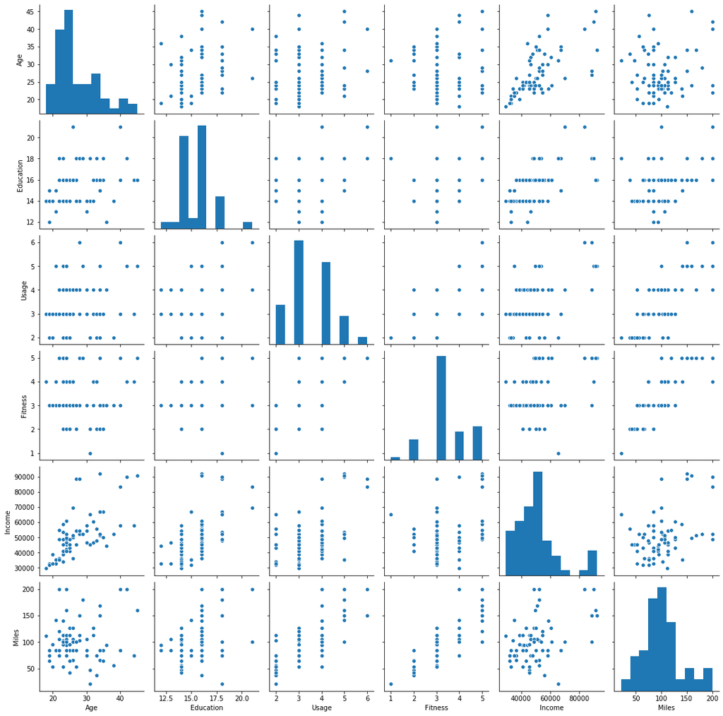

```python
sns.pairplot(cardio_good_fitness_single);
```

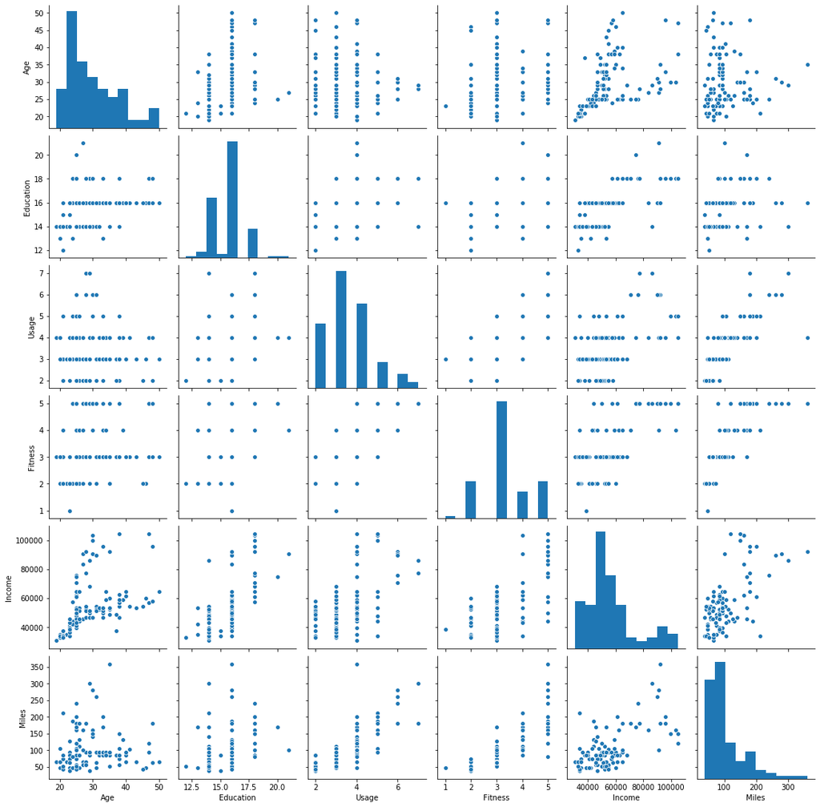

```python
sns.pairplot(cardio_good_fitness_partnered);
```

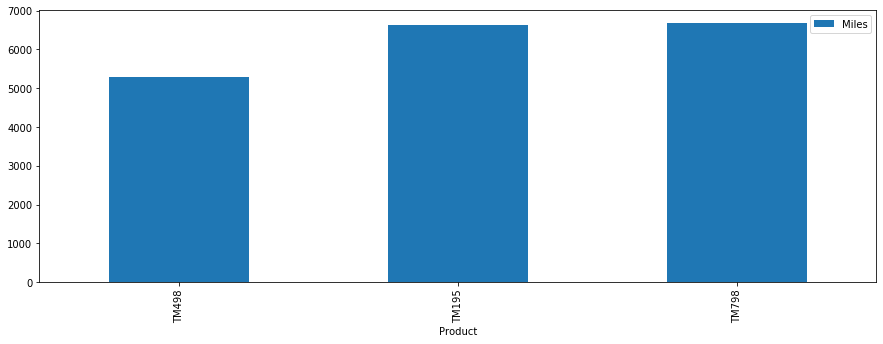

```python
cardio_good_fitness.groupby(by = ['Product'])['Miles'].sum().reset_index().sort_values(['Miles']).tail(10).plot(x = 'Product', y = 'Miles', kind = 'bar', figsize = (15, 5));
```

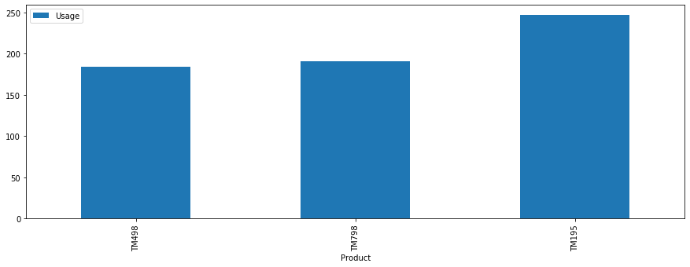

```python
cardio_good_fitness.groupby(by = ['Product'])['Usage'].sum().reset_index().sort_values(['Usage']).tail(10).plot(x = 'Product', y = 'Usage', kind = 'bar', figsize = (15, 5));
```

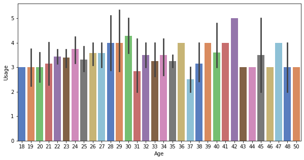

```python
plt.figure(figsize = (10, 5))
ax = sns.barplot(x = 'Age', y = 'Usage', data = cardio_good_fitness, palette = 'muted')
```

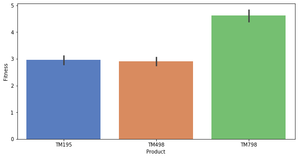

```python
plt.figure(figsize = (10, 5))
ax = sns.barplot(x = 'Product', y = 'Fitness', data = cardio_good_fitness, palette = 'muted')
```

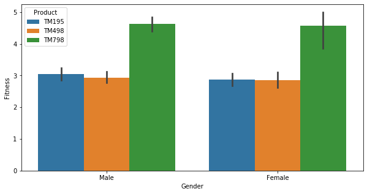

```python
plt.figure(figsize = (10, 5))
ax2 = sns.barplot(x = 'Gender', y = 'Fitness', data = cardio_good_fitness, hue = 'Product')
```

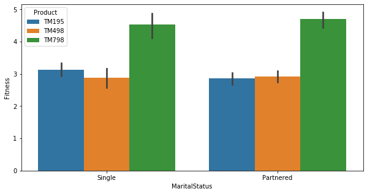

```python
plt.figure(figsize = (10, 5))
ax2 = sns.barplot(x = 'MaritalStatus', y = 'Fitness', data = cardio_good_fitness, hue = 'Product')
```

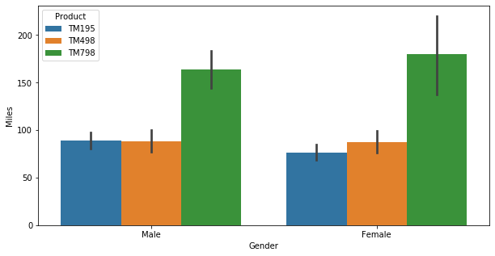

```python
plt.figure(figsize = (10, 5))
ax2 = sns.barplot(x = 'Gender', y = 'Miles', data = cardio_good_fitness, hue = 'Product')
```

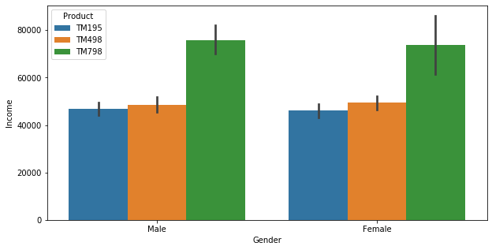

```python
plt.figure(figsize = (10, 5))
ax2 = sns.barplot(x = 'Gender', y = 'Income', data = cardio_good_fitness, hue = 'Product')
```

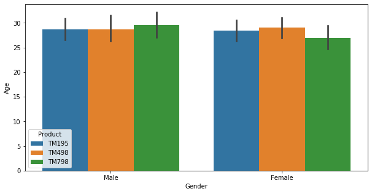

```python
plt.figure(figsize = (10, 5))
ax2 = sns.barplot(x = 'Gender', y = 'Age', data = cardio_good_fitness, hue = 'Product')
```

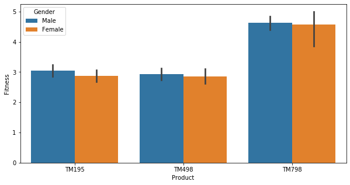

```python
plt.figure(figsize = (10, 5))
ax2 = sns.barplot(x = 'Product', y = 'Fitness', data = cardio_good_fitness, hue = 'Gender')
```

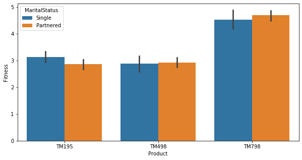

```python
plt.figure(figsize = (10, 5))
ax2 = sns.barplot(x = 'Product', y = 'Fitness', data = cardio_good_fitness, hue = 'MaritalStatus')
```

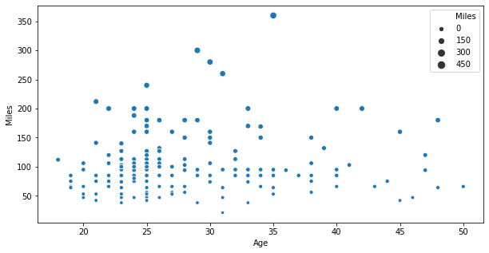

```python
plt.figure(figsize = (10, 5))
ax4 = sns.scatterplot(x = cardio_good_fitness['Age'], y = 'Miles', data = cardio_good_fitness, size = 'Miles');
```

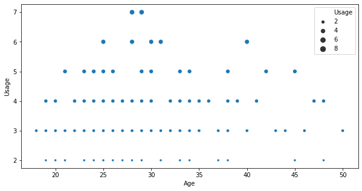

```python
plt.figure(figsize = (10, 5))
ax4 = sns.scatterplot(x = cardio_good_fitness['Age'], y = 'Usage', data = cardio_good_fitness, size = 'Usage');
```

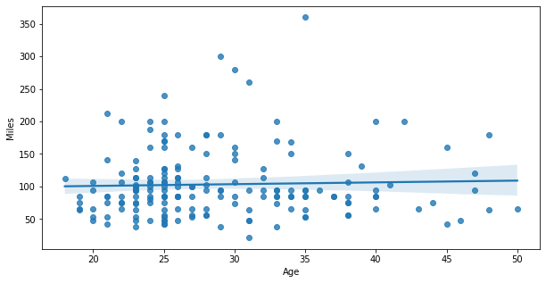

```python
plt.figure(figsize = (10, 5))
sns.regplot(x = 'Age', y = 'Miles', data = cardio_good_fitness);
```

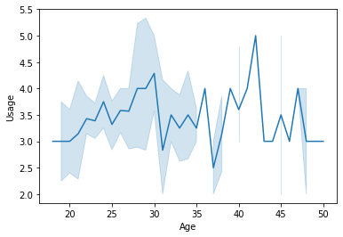

```python
sns.lineplot(x = 'Age', y = 'Usage', data = cardio_good_fitness);
```

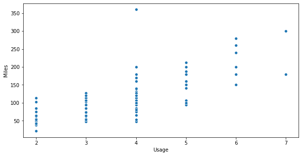

```python
plt.figure(figsize = (10, 5))
sns.scatterplot(x = 'Usage', y = 'Miles', data = cardio_good_fitness);
```

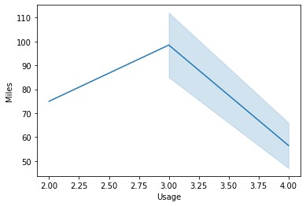

```python
sns.lineplot(x = 'Usage', y = 'Miles', data = cardio_good_fitness.head());
```

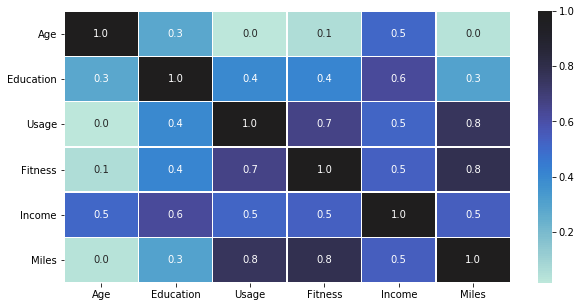

```python
plt.figure(figsize = (10, 5))
sns.heatmap(cardio_good_fitness.corr(), annot = True, linewidth = .5, fmt = '.1f', center = 1);
```

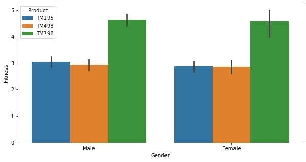

```python
plt.figure(figsize = (10, 5))
sns.barplot(data = cardio_good_fitness, x = 'Gender', y = 'Fitness', hue = 'Product');
```

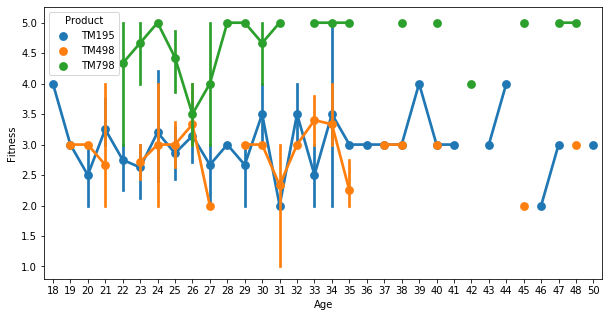

```python
plt.figure(figsize = (10, 5))
sns.pointplot(x = 'Age', y = 'Fitness', hue = 'Product', data = cardio_good_fitness);
```

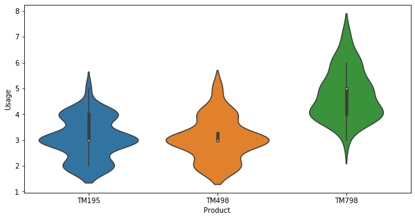

```python
plt.figure(figsize = (10, 5))
sns.violinplot(x = cardio_good_fitness.Product, y = cardio_good_fitness['Usage']);
```

## Customer Profile

- Age: 18 - 50 with an average age of 29
- Customers use the product between 2 and 7 days a week with an average of 3 or 4 days a week
- Customers in the sample set were 58% male and 42% female
- 59% of customers are partnered, leaving 41% single
- On the average, customers experienced higher usage and milage, and had reported higher levels of fitness with the TM798 product
- Customers with a higher income level tended to use the TM798 over the other products available
- The sample data contained 44% tm195 users, 33% tm498 users, 22% tm798 users

## Insights and Recommendations for Targeting New Customers

- The most revenue is likely achieved by targeting partnered males in their thirties with higher income levels
- The TM798 is the best product to focus on, as customers are using it more frequently and getting better overal results
- Only 22% of customers are currently using the TM798 rather than other models